# Teste dos modelos de classificação de proposições

16/05/2019

## Procedimentos

### Dados

- Dados: 967 proposições classificadas manualmente;
  - Bag of words: palavras e bi-grams que apareceram pelo menos 4 proposições diferentes;
  - Removidas: proposições, artigos, números, palavras recorrentes (e.g., Art. e Lei);
  - Matrizes finais: 2763 palavras e bi-grams;

### Modelos

- Modelos: Naive Bayes e Support Vector Machine;
  - Base de treino: 700 observações sorteadas aleatoriamente;
  - Base de teste: 267 observações não sorteadas anteriormente;

### Testes

- Teste: 1000 simulações, ou sorteios;
  - Acurácia: $\frac{positivos + negativos}{(positivos + negativos + falsos~positivos + falsos~negativos)}$;
  - Precisão: $\frac{positivos}{(positivos + falsos~positivos)}$;
  - Recall: $\frac{positivos}{(positivos + falsos~negativos)}$;

## Resultados

Os gráficos abaixo resumem os resultados das 1000 simulações. As densidades indicam a distribuição das estatísticas de interesse (acurácia, precisão e recall) para cada modelo (Naive e SVM) e para cada uma das duas OSC (Alana e ACT). Em todos os eixos X, valores mais próximos de 1 indicam maior desempenho do modelo em determinada estatística (e.g., uma acurácia igual a 1 significa que todas as proposição no set de teste foram classificadas correntamente).

### Teste de Acurácia

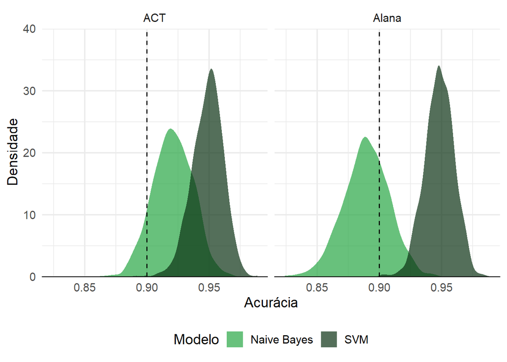

### Teste de Precisão

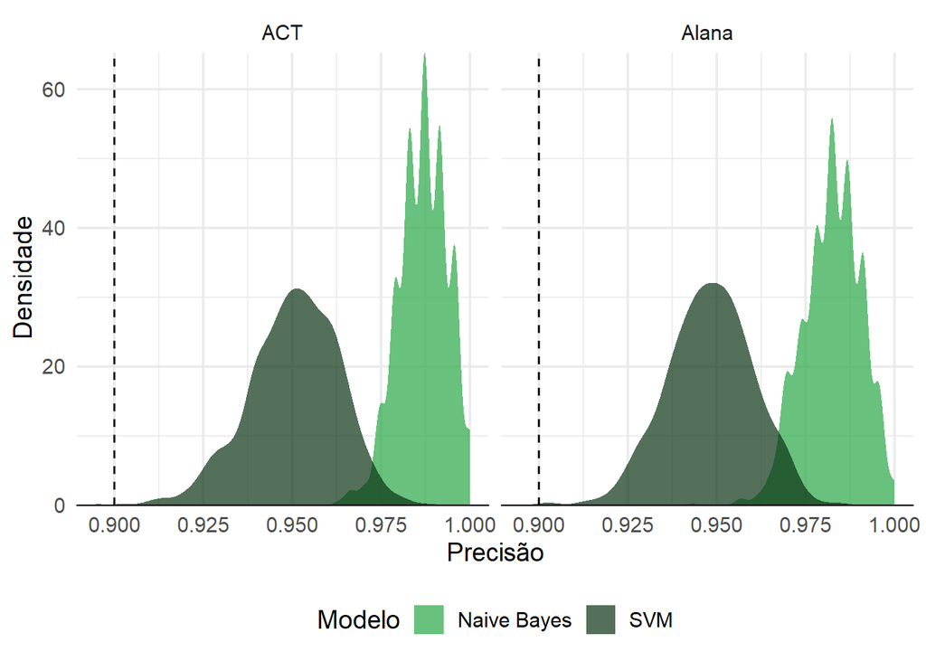

### Teste de Recall

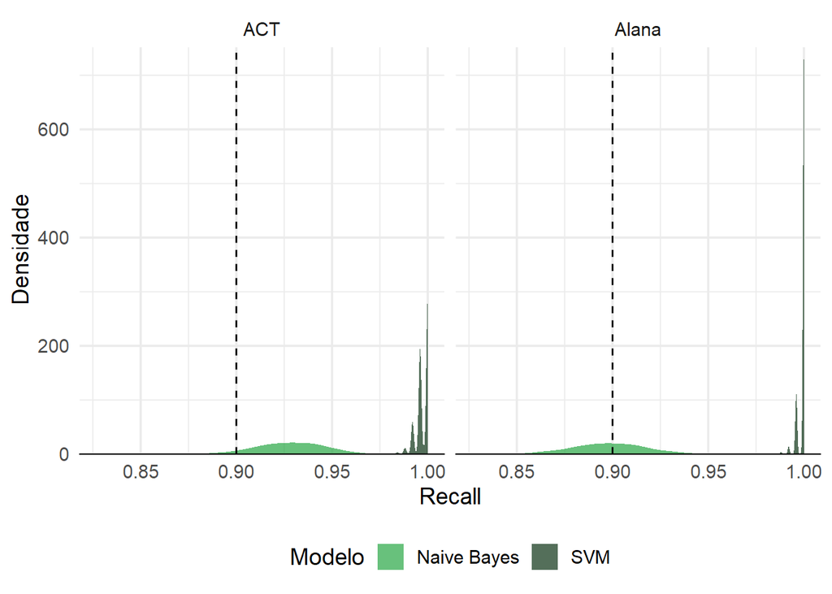

## Conclusão

A acurácia dos modelos de SVM foi maior ao classificar proposições de interessa da Alana e da ACT (em média, de 0.95 tanto para a Alana quanto para a ACT. Mais importante, o recall desses modelos também foi maior – o que significa que eles deixaram menos falsos negativos passarem (i.e., projetos de interesse das organizações parceiras erroneamente descartados). O Naive Bayes só parece um pouco melhor ao evitar falsos positivos.